# Coursework Report

*N* removed NAs: 2

*N* removed <18: 15

*N* total clean: 131

| Group | *N* | *M*<sub>age</sub> | *M*<sub>rating</sub> |
| --- | --- | --- | --- |
| Control | 68 | 20.8 | 5.94 |
| Experim | 63 | 20.7 | 6.08 |

**Main analysis results**

*t*(129) = -1, *p* = .320

# Coursework Report

Analysing Data, Spring 2020

# Methods

## Participants

Table 1 illustrates the two coloured conditions: White and Red. Followed by the number of participants, the mean and standard deviation of age of each condition.

Table 1 *Descriptive statistics by colour condition*

| Condition | *N* | *M*<sub>age</sub> | *SD*<sub>age</sub> |
| --- | --- | --- | --- |
| white | 68 | 20.8 | 1.74 |
| red | 63 | 20.7 | 1.81 |

## Design

our research has replicated Elliot et al. (2010)’s first original experiment, which plans to investigate if women’s attractive perception of a man is influenced by colour. The main variables in the study are colour and perceived attractiveness ratings. Colour is an independent categorical variable with two levels: red colour as the experimental condition and white colour as the control condition. For that reason, the experiment will be using the between-subjects design including the red and white colour condition, acting on the dependent variable of a 9-point likert scale on perceived attractiveness.

In the start of the experiment, a photograph of an attractive young man with either a red or white background frame is shown to a participant for 5 seconds. In the following, they have been asked to rate the perceived attractiveness of each photograph using three face-valid items. The questions are as follows: “How attractive is this person?”, “How pleasant does this person look”, and “If meeting this person, I would find him attractive”. The 9-point Likert scale ranges from, 1 = not attractive at all to 9 = being the most attractive.

This leads to our operational hypothesis of : viewing a photograph of an attractive man with a different colour frame will have an effect on the mean attractiveness ratings scores. Independent measure *t*-test will be used to determine if there is a significant difference in attractiveness between the red and white frame colour condition.

# Results

An independent *t*-test design was used to examine if the participant’s attractiveness response would differ in each colour condition. The 3 attractiveness questionnaires have been averaged to create a composite score of the mean attractiveness response for both sample groups .

The participants scored slightly higher in the mean attractiveness rating for the red condition (*M* = 6.08) than the white condition = (*M* = 5.94). The difference in sample means is not significant (*M*<sub>diff</sub> = -0.14). (*M*<sub>diff</sub> = -0.14, 95% CI [-0.43, 0.14], *t* (129) = -1, *p* = 0.32).

The t-value was calculated by the differences of the standard error of differences between the mean samples. Firstly, the standard deviation of each condition was identified , the SD value of the red condition is *SD* = 0.82 and white *SD* = 0.83 . This Result in the standard deviation of differences between the sample means of (*SD*<sub>diff</sub> = -0.01), this is used to work out *t*-value = -1

we can conclude that the differences between the sample means of -0.14 was -1 times bigger than the Standard error of differences in means. The larger the t-value, the bigger the difference between sample means compared to the standard error.

However, due to the small t-value, there is a possibility that the null hypothesis could be true. Therefore, we can compare our probability of the value being a true difference in means, *p* = 0.32, to the significance codes of p < .001. This can prove that our probability is much larger than the significance code. Consequently, it is likely that the two samples came from the same population, so we accept the null hypothesis and reject the alternative hypothesis, which states that these two samples came from a different population.

To conclude this, the analysis suggests no significant difference in the mean attractiveness rating of the red and white frame colour conditions (*M*<sub>diff</sub> = -0.14, 95% CI [-0.43, 0.14], *t* (129) = -1, *p* = 0.32).

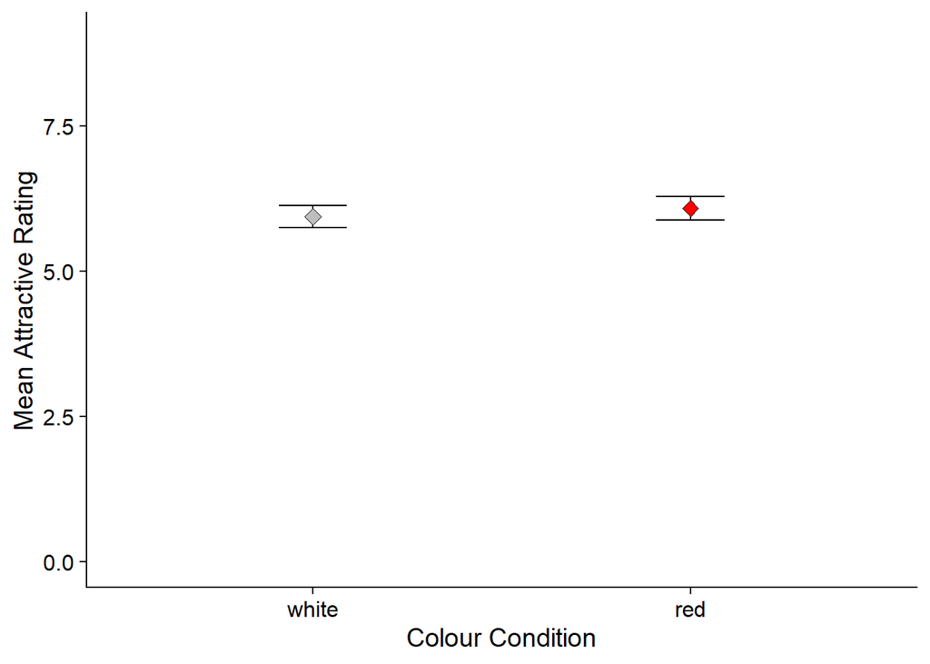

*Figure 2*. illustrate the Mean Attractiveness Rating by the white and red frame conditions.

# Discussion

My research planned to investigate whether colour has an influence on women’s attraction to men, which my study had replicated from the original Elliot et al. (2010) study. He concluded that women would rate a man more attractive when presented with a red background compared to a white background, showing evidence for the “red” colour having an influence on women’s attraction to men. In contrast to Elliot et al. (2010) findings, we found that colour had no effect on the attractiveness ratings to men , indicating that the red effects may not be as influential on men’s attraction as we have previously thought.

There is compelling evidence to support my findings, For example, Hesslinger and Pepperkoon, (2015) have both failed to find a significant result that would support the red effects. In the same way, Elliot & Maier, (2013) replicated the original Elliot et al study with a bigger sample size to 144 participants compared to the original . He found his result to be inconclusive, meaning the red effects were found to be non-significant on the attractiveness rating.These studies have been consistent with our result.

Furthermore, part of the reason why my result was found to be non-significant could perhaps be that the association between the red colour and attraction may have changed overtime. Enda, (2012) discussed the importance of how the political colours of ‘’red” and “blue states” arised in the United States. The red and blue colours have been fluid with identifying with a certain american political party. This had all changed in the 2000, when the New York Times published the first colour coded newspaper with red associated with Republication and blue associated with democratic, and this was important in setting colour trends in political field, as soon followed, the US media would adopt the same colours when shown an election map of red associated with republican and blue with democratic candidate. Therefore, it could be the case that the red colour is a fluid phenomenon that can easily be influenced through the media and cultural norms.

One could argue that the poor interpretation of the study led to a significant result on the red effects. Francis (2013) criticised Elliot et al. (2010) that his findings may have been subjected to publication bias. He argued that there is a very low chance for all of the experimental results to consistently reject the null hypothesis. Thus, there is a possibility that the null findings may have been left undeclared.

This is an immense problem within the Educational Psychology research area, as positive results are in favour and are more likely to be published. Leaving the null findings to be left undiscovered. The consequences of this leads to an unnecessary risk in harming research participants and wasting resources that could have been avoidable. Therefore, the norms about publishing negative results should be encouraged (Kepes et al., 2014).

Nevertheless, a few limitations have been identified in my study. First of all, the use of the rating scale is a very subjective measurement, due to our individual differences in men preference. For instance, women may rate the Caucasian model as more attractive throughout, if they have a preference towards Caucasian men. Hence, in the future it is important to include a diverse set of models from different ethnicities, which would prevent a type of bias and allow for a more accurate interpretation of attraction.

Additionally, the participant’s age in my study had ranged from 18-27 years old, this is an issue because we cannot comment that the red effects do not affect attraction to all the women, as this does not include participants in the older range. On top of this, Hesslinger et al. (2015) second experiment, included female undergraduates in his study, with a similar age range to our study (19-26). He found no significant differences of the red effects on attraction. Thus, in order to extrapolate the findings to the general female population, and find a true red effect, we need to have a diverse set of sample groups from different ages and classes.

However, as a whole, most researches into the red effects on women’s attraction to men, have found that the red effects to be substantially small or insignificant, in comparison to studies of men’s attraction to women. Lehmann et al. (2018) ran a meta-analysis on studies into red effects on attraction on both men and women. He found that the true red effects are small in attractiveness studies on women compared to studies on men. One of the reasons was due to a small sample size. Perhaps in order to find a true red effect, I need to increase my sample size, even though my participants numbers were 131 ; this was split into the two conditions leaving 68 and 63 participants in each condition. Therefore, in the future,conducting a within study design can increase the sample size and reliability of the study.

In summary, even though our results were not consistent with Elliot et al. (2010) findings, we cannot conclude that the colour “red” does not have an effect on attraction as we were limited by the small sample size and the lack of diverse ethnicities. Or perhaps we need to fix the broken system within the Educational Psychology research to ensure all results are published even if this meant the null findings are published. However, due to an increased complexity in our environment, the red effects may have already evolved away from attraction and that the meaning of red differs individually due to the influence from the media, internet and norms.

# References

Elliot, A. J., & Maier, M. A. (2013). The red-attractiveness effect, applying the Ioannidis and

Trikalinos (2007b) test, and the broader scientific context: A reply to Francis (2013). *Journal of Experimental Psychology: General, 142*(1), 297–300. https://doi.org/10.1037/a0029592

Elliot, A. J., Niesta Kayser, D., Greitemeyer, T., Lichtenfeld, S., Gramzow, R. H., Maier, M. A.,

& Liu,H. (2010). Red, rank, and romance in women viewing men. *Journal of Experimental Psychology: General, 139*(3), 399–417. https://doi.org/10.1037/a0019689

Enda, J. (2012, October). When Republicans Were Blue and Democrats Were Red.

*Smithsonian Magazine*. Retrieved from  
https://www.smithsonianmag.com/history/when-republicans-were-blue-and-democrats-were-red-10417629/

Francis, G. (2013). Publication bias in “Red, rank, and romance in women viewing men,”

by Elliot et al. (2010). *Journal of Experimental Psychology: General, 142*(1), 292–296. https://doi.org/10.1037/a0027923

Hesslinger, V. M., Goldbach, L., & Carbon, C.-C. (2015). Men in red: A reexamination of the

red-attractiveness effect. *Psychonomic Bulletin & Review, 22*(4), 1142–1148.  
https://doi.org/10.3758/s13423-015-0866-8

Kepes, S., Banks, G. C., & Oh, I. (2014). Avoiding Bias in Publication Bias Research: The Value of ‘Null’

Findings. *Journal of Business and Psychology; New York*, 29(2), 183–203.  
http://dx.doi.org/10.1007/s10869-012-9279-0

Lehmann, G. K., Elliot, A. J., & Calin-Jageman, R. J. (2018). Meta-Analysis of the Effect of Red on

Perceived Attractiveness. *Evolutionary Psychology, 16*(4),1474704918802412.  
https://doi.org/10.1177/1474704918802412

Peperkoorn, L. S., Roberts, S. C., & Pollet, T. V. (2016). Revisiting the Red Effect on Attractiveness and

Sexual Receptivity: No Effect of the Color Red on Human Mate Preferences. *Evolutionary Psychology,14*(4), 147470491667384. https://doi.org/10.1177/1474704916673841